# What affects World Happiness?

Brandon Pugh

October 02, 2020

## Introduction

What is happiness? Many have tried to answer this question, and no one really has found a clear, definitive answer to this question. The World Happiness Organization is one of these groups, and have spent years gathering data of different socio-economic factors to compile, what they call, the “life ladder”. This is how they measure the happiness of a country, and contains a value from 0 to 10, with 0 being the lowest value of happiness and 10 being the highest. The closer a country’s life ladder value, the happier it’s citizens are. The purpose of this analysis is to determine what socio-economic factors have an impact on a nation’s happiness, and use that information to find out which nations are doing the worse at those significant factors so that the UN can direct policy to try to improve the situation in those countries.

## Data Overview

### Data Source and References

The data that is used in this analysis is contained within the file “HappyData.csv”, which is stored in the Happiness folder on the main branch of the GitHub site listed below:

https://github.com/Pughbt/_ISA616HappinessProject

### Variable Information

The following are the variables that are included in the data set with their definition:

**Country.name** is the name of the country

**year** is the year of which the data was created.

**Life.Ladder** is the happiness score for that country in that specific year. It is on a scale from 0 to 10, with 0 being absolutely unhappy and 10 being extremely happy.

**Log.GDP.per.capita** is the log value of a nation’s GDP per capita

**Social.Support** is the percentage of people in a country that says that they have someone to count on in times of trouble.

**Healthy.life.expectancy.at.birth** is the average life expectancy for a person at birth Freedom.to.make.life.choices is the national average of the citizen’s belief on the amount of freedom in their lives

**Generosity** is the residual of regressing national average of response to the GWP question “Have you donated money to a charity in the past month?” on GDP per capita.

**Perceptions.of.corruption** is the percentage of people in a country that believe that their government has widespred corruption

**Positive.affect** is the average of how many times a person feels happy in a day.

**Negative.affect** is the average of how many times a person feels sad/angry/worried in a day

**Confidence.in.national.government** is the average of how many peole who have confidence in their government

**Democratic.Quality** is how democratic a country’s government is. **Delivery.quality** is also measures the same thing.

**Standard.deviation.of.ladder.by.country.year** is an alternative measure of hte inequality of happiness. **Standard.deviation.mean.of.ladder.by.country.year** is the mean of the previous variable

The **GIN**I world index variables measures World bank data for a country

The **most.people.can.be.trusted variables** is the average percentage of people in a country that most people can be trused, with most of the variables being that for different time periods.

### Data Summary

```r
##Loading in all required packages for the analysis
pacman:: p_load(DataExplorer, dplyr, corrplot)

## Reading in the data
happiness = read.csv("Happiness/HappyData.csv", stringsAsFactors = TRUE)

##Showing the dimension of the data
dim(happiness)
```

```
## [1] 1848   26
```

The data has 1848 different observations across 26 variables. Each row is a unique combination of the country name and the year for which data was collected.

```r
## Provides summary statistics for the happiness data set
summary(happiness)
```

```
##      Country.name       year       Life.Ladder    Log.GDP.per.capita
##  Argentina :  14   Min.   :2005   Min.   :2.375   Min.   : 6.457
##  Azerbaijan:  14   1st Qu.:2010   1st Qu.:4.623   1st Qu.: 8.309
##  Bangladesh:  14   Median :2013   Median :5.363   Median : 9.408
##  Belarus   :  14   Mean   :2013   Mean   :5.446   Mean   : 9.245
##  Bolivia   :  14   3rd Qu.:2016   3rd Qu.:6.268   3rd Qu.:10.209
##  Brazil    :  14   Max.   :2019   Max.   :8.019   Max.   :11.728
##  (Other)   :1764                                  NA's   :29
##  Social.support   Healthy.life.expectancy.at.birth Freedom.to.make.life.choices
##  Min.   :0.2902   Min.   :32.30                    Min.   :0.2575
##  1st Qu.:0.7483   1st Qu.:58.30                    1st Qu.:0.6431
##  Median :0.8340   Median :65.10                    Median :0.7575
##  Mean   :0.8111   Mean   :63.17                    Mean   :0.7385
##  3rd Qu.:0.9046   3rd Qu.:68.39                    3rd Qu.:0.8524
##  Max.   :0.9873   Max.   :77.10                    Max.   :0.9852
##  NA's   :13       NA's   :52                       NA's   :31
##    Generosity       Perceptions.of.corruption Positive.affect
##  Min.   :-0.33177   Min.   :0.0352            Min.   :0.3217
##  1st Qu.:-0.11718   1st Qu.:0.6927            1st Qu.:0.6233
##  Median :-0.02372   Median :0.8036            Median :0.7208
##  Mean   : 0.00011   Mean   :0.7491            Mean   :0.7096
##  3rd Qu.: 0.09115   3rd Qu.:0.8737            3rd Qu.:0.8011
##  Max.   : 0.67992   Max.   :0.9833            Max.   :0.9436
##  NA's   :83         NA's   :103               NA's   :21
##  Negative.affect   Confidence.in.national.government Democratic.Quality
##  Min.   :0.08343   Min.   :0.06877                   Min.   :-2.4483
##  1st Qu.:0.20595   1st Qu.:0.33641                   1st Qu.:-0.7885
##  Median :0.25577   Median :0.46479                   Median :-0.2259
##  Mean   :0.26721   Mean   :0.48316                   Mean   :-0.1350
##  3rd Qu.:0.31800   3rd Qu.:0.61626                   3rd Qu.: 0.6531
##  Max.   :0.70459   Max.   :0.99360                   Max.   : 1.5825
##  NA's   :15        NA's   :191                       NA's   :149
##  Delivery.Quality   Standard.deviation.of.ladder.by.country.year
##  Min.   :-2.14497   Min.   :0.863
##  1st Qu.:-0.71114   1st Qu.:1.747
##  Median :-0.21663   Median :1.987
##  Mean   :-0.00209   Mean   :2.052
##  3rd Qu.: 0.69965   3rd Qu.:2.280
##  Max.   : 2.18472   Max.   :4.073
##  NA's   :148
```

[output cut: 73 more lines]

```
##  Min.   :0.0382
##  1st Qu.:0.1435
##  Median :0.1984
##  Mean   :0.2643
##  3rd Qu.:0.3914
##  Max.   :0.7373
##  NA's   :1164
##  Most.people.can.be.trusted..WVS.round.2010.2014
##  Min.   :0.0315
##  1st Qu.:0.1187
##  Median :0.1935
##  Mean   :0.2372
##  3rd Qu.:0.3350
##  Max.   :0.6618
##  NA's   :1124
```

## Data Cleaning and PreProcessing

Before we can start building our model, we first have to go through our data and check various items to see if we can reduce our model. By reducing our model, we can make our analysis that much more efficient and accurate.

### Missing Data

The first thing we should check for is the missingness of our data. The general rule of thumb is that if a variable has more than **50%** of it’s values missing, it is then dropped from the data set.

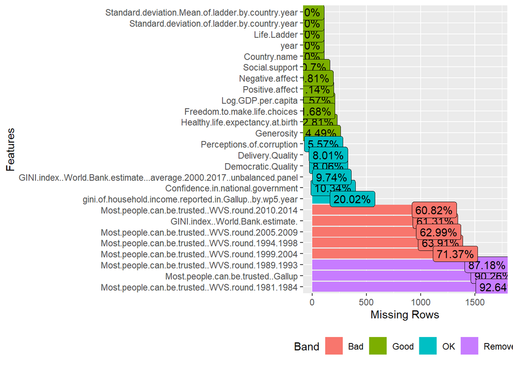

```r
##Plot the missingness of the data
plot_missing(happiness)
```

As seen in the above chart, the variables that have bars that are either red or purple have their percentage of missing values greater than 50%. These are then dropped from the dataset as they would not provide much information due to their high amounts of missingness.

```r
happiness = select(happiness, -Most.people.can.be.trusted..Gallup)
happiness = select(happiness, -Most.people.can.be.trusted..WVS.round.1981.1984)
happiness = select(happiness, -Most.people.can.be.trusted..WVS.round.1989.1993)
happiness = select(happiness, -Most.people.can.be.trusted..WVS.round.1994.1998)
happiness = select(happiness, -Most.people.can.be.trusted..WVS.round.1999.2004)
happiness = select(happiness, -Most.people.can.be.trusted..WVS.round.2005.2009)
happiness = select(happiness, -Most.people.can.be.trusted..WVS.round.2010.2014)
happiness = select(happiness, -GINI.index..World.Bank.estimate.)
```

### Renaming variables

The following variables were renamed due to their length being too long for the visuals that follow in this report to be visible:

**Standard.deviation.of.ladder.by.country.year** was renamed to **sdofhappiness** **Standard.deviation.Mean.of.ladder.by.country.year** was renamed to **meansdofhappiness** **GINI.index..World.Bank.estimate…average.2000.2017..unbalanced.panel** was renamed to **GINIWorldBank** **gini.of.household.income.reported.in.Gallup..by.wp5.year** was renamed to **GINIHousehold**

```r
##Rename variables and drop old ones
happiness$sdofhappiness = happiness$Standard.deviation.of.ladder.by.country.year
happiness = select(happiness, -Standard.deviation.of.ladder.by.country.year)
happiness$meansdofhappiness = happiness$Standard.deviation.Mean.of.ladder.by.country.year
happiness = select(happiness, -Standard.deviation.Mean.of.ladder.by.country.year)
happiness$GINIWorldBank = happiness$GINI.index..World.Bank.estimate...average.2000.2017..unbalanced.panel
happiness = select(happiness, -GINI.index..World.Bank.estimate...average.2000.2017..unbalanced.panel)
happiness$GINIHousehold = happiness$gini.of.household.income.reported.in.Gallup..by.wp5.year
happiness = select(happiness, -gini.of.household.income.reported.in.Gallup..by.wp5.year)
```

### Correlation

The next thing that we have to check before we can do our analysis is to check the correlation of the remaining variables in the data set. If we find variables that are highly correlated, one of them will be removed since both of the variables explain the same information. It would make the data redundant in the analysis.

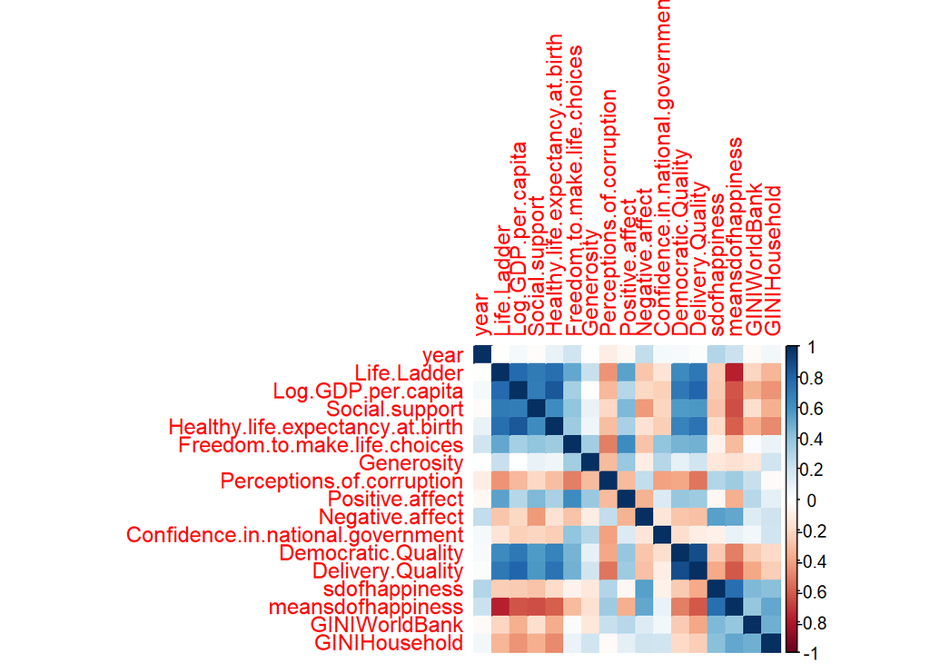

```r
##Show the correlation for the variables left in the data set

## Turns the data set into only numeric variables
happiness_numeric = select(happiness, -Country.name)
## Creates a matrix of the correlations
M = cor(happiness_numeric, use = "complete.obs")

##Creates the correlation plot
corrplot(M, method = "color")
```

In the above correlation plot, we see that **Democratic.Quality** and **Delivery.Quality** are highly correlated with each other. The variable that was dropped was delivery.quality.

```r
##Drop highly correlated variabels
happiness = select(happiness, -Delivery.Quality)
```

### Data Aggregation

```r
head(happiness)
```

```
##   Country.name year Life.Ladder Log.GDP.per.capita Social.support
## 1  Afghanistan 2008    3.723590           7.144916      0.4506623
## 2  Afghanistan 2009    4.401778           7.314788      0.5523084
## 3  Afghanistan 2010    4.758381           7.421525      0.5390752
## 4  Afghanistan 2011    3.831719           7.394349      0.5211036
## 5  Afghanistan 2012    3.782938           7.480296      0.5206367
## 6  Afghanistan 2013    3.572100           7.499845      0.4835519
##   Healthy.life.expectancy.at.birth Freedom.to.make.life.choices Generosity
## 1                            50.80                    0.7181143 0.17899305
## 2                            51.20                    0.6788964 0.20122828
## 3                            51.60                    0.6001272 0.13157794
## 4                            51.92                    0.4959014 0.17345162
## 5                            52.24                    0.5309350 0.24694321
## 6                            52.56                    0.5779554 0.07203268
##   Perceptions.of.corruption Positive.affect Negative.affect
```

[output cut: 20 more lines]

```r
##Aggregating the data
happiness.agg = happiness %>%
  group_by(Country.name) %>%
  summarize(avg.Life.Lader = mean(Life.Ladder, na.rm = T),
            avg.log.GDP.per.capita = mean(Log.GDP.per.capita, na.rm = T),
            avg.social.support = mean(Social.support, na.rm =T),
            avg.life.expectancy = mean(Healthy.life.expectancy.at.birth, na.rm = T),
            avg.freedom = mean(Freedom.to.make.life.choices, na.rm = T),
            avg.generosity = mean(Generosity, na.rm = T),
            avg.perception.of.corrpution = mean(Perceptions.of.corruption, na.rm = T),
            avg.positive.affect = mean(Positive.affect, na.rm = T),
            avg.negative.affect = mean(Negative.affect, na.rm = T),
            avg.confidence.in.government = mean(Confidence.in.national.government, na.rm = T),
            avg.democratic.quality = mean(Democratic.Quality, na.rm = T),
            avg.sd.of.happiness = mean(sdofhappiness, na.rm = T),
            avg.mean.sd.of.happiness = mean(meansdofhappiness, na.rm = T),
            avg.GINI.world.bank = mean(GINIWorldBank, na.rm = T),
            avg.gini.household = mean(GINIHousehold, na.rm = T)
            )
```

Now the data set will look like the table below:

```r
head(happiness.agg)
```

```
## # A tibble: 6 x 16
##   Country.name avg.Life.Lader avg.log.GDP.per~ avg.social.supp~ avg.life.expect~
##   <fct>                 <dbl>            <dbl>            <dbl>            <dbl>
## 1 Afghanistan            3.59             7.42            0.508             52.3
## 2 Albania                4.99             9.28            0.717             67.4
## 3 Algeria                5.39             9.51            0.804             65.3
## 4 Angola                 4.42             8.80            0.738             53.6
## 5 Argentina              6.34             9.83            0.905             67.8
## 6 Armenia                4.44             8.93            0.714             65.6
## # ... with 11 more variables: avg.freedom <dbl>, avg.generosity <dbl>,
## #   avg.perception.of.corrpution <dbl>, avg.positive.affect <dbl>,
## #   avg.negative.affect <dbl>, avg.confidence.in.government <dbl>,
## #   avg.democratic.quality <dbl>, avg.sd.of.happiness <dbl>,
## #   avg.mean.sd.of.happiness <dbl>, avg.GINI.world.bank <dbl>,
## #   avg.gini.household <dbl>
```

This makes the analysis much easier to perform and interpret as we no longer have to worry about time differences in the data.

### Missing Data in the Aggregate

Now that we have aggregated the data, we now have to check to see if there is any missing data with the aggregates.

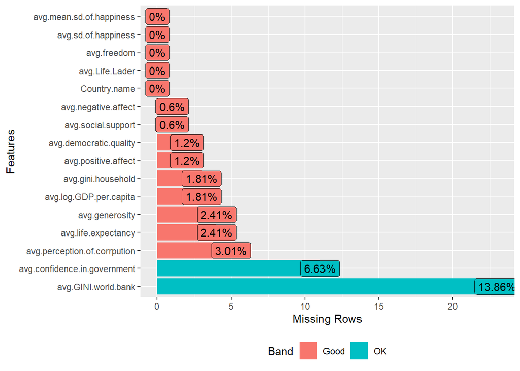

```r
plot_missing(happiness.agg)
```

We see that even after the aggregation, there are still missing values for certain variables. This means that for the certain country, no data was recorded for that variable.

So how do we handle these missing variables? Since there is not a lot of missing values, we can input the data into ourselves. We do this by replacing the missing values with the average value for that variable for the rest of the observations. This way the analysis can be completed without making drastic changes to the data.

```r
rows = which(is.nan(happiness.agg$avg.confidence.in.government))
happiness.agg$avg.confidence.in.government[rows] = mean(happiness.agg$avg.confidence.in.government, na.rm = T)

rows1 = which(is.nan(happiness.agg$avg.negative.affect))
happiness.agg$avg.negative.affect[rows1] = mean(happiness.agg$avg.negative.affect, na.rm = T)

rows2 = which(is.nan(happiness.agg$avg.social.support))

happiness.agg$avg.social.support[rows2] = mean(happiness.agg$avg.social.support, na.rm = T)

rows3 = which(is.nan(happiness.agg$avg.democratic.quality))
happiness.agg$avg.democratic.quality[rows3] = mean(happiness.agg$avg.democratic.quality, na.rm = T)

rows4 = which(is.nan(happiness.agg$avg.positive.affect))
happiness.agg$avg.positive.affect[rows4] = mean(happiness.agg$avg.positive.affect, na.rm = T)

rows5 = which(is.nan(happiness.agg$avg.gini.household))
happiness.agg$avg.gini.household[rows5] = mean(happiness.agg$avg.gini.household, na.rm = T)

rows6 = which(is.nan(happiness.agg$avg.log.GDP.per.capita))
happiness.agg$avg.log.GDP.per.capita[rows6] = mean(happiness.agg$avg.log.GDP.per.capita, na.rm = T)

rows7 = which(is.nan(happiness.agg$avg.generosity))
happiness.agg$avg.generosity[rows7] = mean(happiness.agg$avg.generosity, na.rm = T)

rows8 = which(is.nan(happiness.agg$avg.life.expectancy))
happiness.agg$avg.life.expectancy[rows8] = mean(happiness.agg$avg.life.expectancy, na.rm = T)

rows9 = which(is.nan(happiness.agg$avg.perception.of.corrpution))
happiness.agg$avg.perception.of.corrpution[rows9] = mean(happiness.agg$avg.perception.of.corrpution, na.rm= T)

rows10 = which(is.nan(happiness.agg$avg.GINI.world.bank))
happiness.agg$avg.GINI.world.bank[rows10] = mean(happiness.agg$avg.GINI.world.bank, na.rm = T)
```

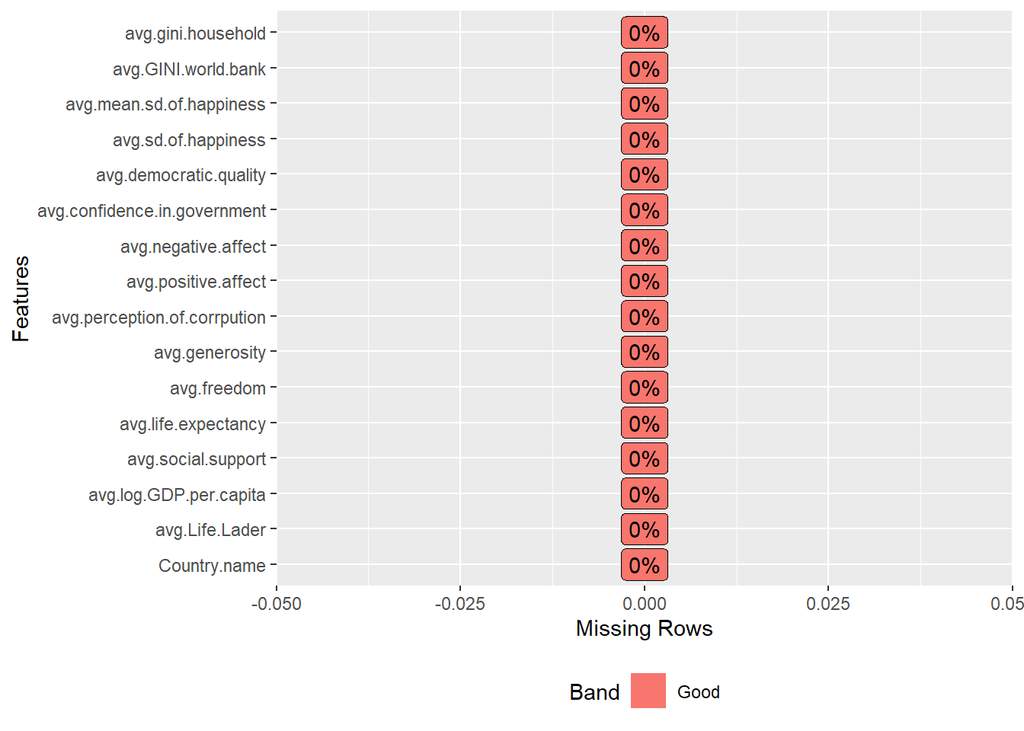

```r
plot_missing(happiness.agg)
```

Now that we have no missing data in this data set, we can start doing our analysis.

## The Model

The first thing we have to do is to determine what type of model we will use to help answer the question of what affects a country’s happiness score. Since this question is explanatory in nature, we can use a multiple linear regression model to perform our analysis. We do not include Country.Name in our model as it would not be useful in explaining happiness. We also do not include sdofhappiness and meansdofhappiness variables as they are related to the response variable and would not be useful in explaining happiness. The results of the modle appear below.

```r
model1 = lm(avg.Life.Lader~ avg.log.GDP.per.capita + avg.social.support + avg.life.expectancy
            + avg.freedom + avg.generosity + avg.perception.of.corrpution + avg.positive.affect
            + avg.negative.affect + avg.confidence.in.government + avg.democratic.quality
             + avg.GINI.world.bank +
              avg.gini.household, data = happiness.agg)
summary(model1)
```

```
##
## Call:
## lm(formula = avg.Life.Lader ~ avg.log.GDP.per.capita + avg.social.support +
##     avg.life.expectancy + avg.freedom + avg.generosity + avg.perception.of.corrpution +
##     avg.positive.affect + avg.negative.affect + avg.confidence.in.government +
##     avg.democratic.quality + avg.GINI.world.bank + avg.gini.household,
##     data = happiness.agg)
##
## Residuals:
##      Min       1Q   Median       3Q      Max
## -1.27218 -0.19585  0.03145  0.24834  0.99431
##
## Coefficients:
##                               Estimate Std. Error t value Pr(>|t|)
## (Intercept)                  -0.290271   0.776667  -0.374  0.70912
## avg.log.GDP.per.capita        0.235136   0.057846   4.065 7.66e-05 ***
## avg.social.support            1.559596   0.486580   3.205  0.00164 **
## avg.life.expectancy           0.021478   0.009088   2.363  0.01937 *
## avg.freedom                   1.148229   0.426793   2.690  0.00793 **
## avg.generosity                0.371759   0.280081   1.327  0.18638
## avg.perception.of.corrpution -1.109425   0.269011  -4.124 6.09e-05 ***
## avg.positive.affect           2.613546   0.615095   4.249 3.72e-05 ***
## avg.negative.affect           1.198361   0.615597   1.947  0.05341 .
## avg.confidence.in.government -1.141896   0.271547  -4.205 4.42e-05 ***
## avg.democratic.quality        0.049839   0.055346   0.900  0.36927
## avg.GINI.world.bank          -0.604028   0.628017  -0.962  0.33767
## avg.gini.household           -1.005165   0.501449  -2.005  0.04678 *
## ---
## Signif. codes:  0 '***' 0.001 '**' 0.01 '*' 0.05 '.' 0.1 ' ' 1
##
## Residual standard error: 0.4172 on 153 degrees of freedom
## Multiple R-squared:  0.856,  Adjusted R-squared:  0.8447
## F-statistic:  75.8 on 12 and 153 DF,  p-value: < 2.2e-16
```

### The Results

After the running of the model, we can know see what factors actually affect the happiness of countries around the world. These variables are avg.log.GDP.per.capita, avg.social.support, avg.life.expectancy, avg.freedom, avg.perception.of.corruption, avg.positive.affect, avg.confidence.in.government, and avg.gini.household

For the following variables, an increase in the variable leads to a increase in a country’s happiness:

**avg.log.GDP.per.capita**

**avg.social.support**

**avg.life.expectancy**

**avg.freedom**

For the following variables, an increase in the variable leads to a decrease in a country’s happiness:

**avg.perception.of.corruption**

**avg.confidence.in.government**

**avg.gini.household**

For almost all of these variables, the way that they affect happiness makes sense. We expect that the richer a country is, the more people that individuals can rely on, the longer a person lives, and the more freedom a person has to live their own life would make a country’s populace. We would also expect the more corrupt a government is and the more variability in a household would lead to a country’s populace to be less happy. But we wouldn’t expect that the higher a country’s populace has confidence in their government leads to that populace being unhappy. You would think that the less confident a country is in their leadership, the less happy they would be. But the opposite occurs. Let’s take a deeper look at this particular variable

#### The avg.confidence.in.government Variable

To explore more of the avg.confidence.in.government variable, we’ll look at the top 20 and bottom 20 countires in terms of this variable, and compare how their happiness values are.

The table below shows the top 20 countries in terms of avg.confidence.in.government:

```r
top_n(happiness.agg, 20, avg.confidence.in.government)
```

```
## # A tibble: 20 x 16
##    Country.name avg.Life.Lader avg.log.GDP.per~ avg.social.supp~
##    <fct>                 <dbl>            <dbl>            <dbl>
##  1 Azerbaijan             4.94             9.64            0.771
##  2 Bangladesh             4.72             7.97            0.598
##  3 Bhutan                 5.20             8.98            0.849
##  4 Botswana               4.00             9.61            0.826
##  5 Burundi                3.55             6.58            0.418
##  6 Cambodia               4.24             7.98            0.719
##  7 Ethiopia               4.38             7.34            0.683
##  8 Gambia                 4.73             7.32            0.692
##  9 Jordan                 5.30             9.09            0.840
## 10 Kuwait                 6.27            11.2             0.873
## 11 Laos                   4.97             8.47            0.741
## 12 Luxembourg             7.05            11.4             0.921
## 13 Myanmar                4.41             8.54            0.753
## 14 Qatar                  6.57            11.7             0.863
## 15 Rwanda                 3.65             7.39            0.619
## 16 Singapore              6.50            11.2             0.881
## 17 Switzerland            7.55            11.0             0.943
## 18 Tajikistan             4.91             7.79            0.764
## 19 Uzbekistan             5.79             8.50            0.928
## 20 Vietnam                5.31             8.52            0.829
## # ... with 12 more variables: avg.life.expectancy <dbl>, avg.freedom <dbl>,
## #   avg.generosity <dbl>, avg.perception.of.corrpution <dbl>,
## #   avg.positive.affect <dbl>, avg.negative.affect <dbl>,
## #   avg.confidence.in.government <dbl>, avg.democratic.quality <dbl>,
## #   avg.sd.of.happiness <dbl>, avg.mean.sd.of.happiness <dbl>,
## #   avg.GINI.world.bank <dbl>, avg.gini.household <dbl>
```

We can now calcualte the average of these nations happiness:

```r
(4.94 + 4.72 + 5.2 + 4 + 3.55 + 4.24 + 4.38 + 4.73 + 5.3 + 6.27 + 4.97 + 7.05 + 4.41 + 6.57 + 3.65 + 6.5 + 7.55 + 4.91 + 5.79 + 5.31)/20
```

```
## [1] 5.202
```

We can also do the same thing for the bottom 20 nations in terms of avg.confidence.in.government

```r
happiness.agg %>%
  arrange((avg.confidence.in.government)) %>%
  slice(1:20)
```

```
## # A tibble: 20 x 16
##    Country.name avg.Life.Lader avg.log.GDP.per~ avg.social.supp~
##    <fct>                 <dbl>            <dbl>            <dbl>
##  1 Ukraine                4.73             9.00            0.873
##  2 Bosnia and ~           5.16             9.29            0.773
##  3 Romania                5.53             9.88            0.782
##  4 Peru                   5.59             9.29            0.803
##  5 Moldova                5.60             8.57            0.836
##  6 Latvia                 5.37            10.0             0.871
##  7 Lebanon                4.98             9.42            0.770
##  8 Greece                 5.53            10.2             0.813
##  9 Bulgaria               4.48             9.73            0.885
## 10 Lithuania              5.79            10.1             0.921
## 11 Italy                  6.27            10.5             0.898
## 12 Slovenia               6.02            10.3             0.927
## 13 Croatia                5.55             9.98            0.809
## 14 Jamaica                5.70             9.01            0.883
## 15 South Korea            5.88            10.4             0.791
## 16 Poland                 5.91            10.1             0.909
## 17 Slovakia               6.02            10.2             0.928
## 18 Paraguay               5.56             9.22            0.906
## 19 Mongolia               4.98             9.21            0.926
## 20 Japan                  6.01            10.5             0.904
## # ... with 12 more variables: avg.life.expectancy <dbl>, avg.freedom <dbl>,
## #   avg.generosity <dbl>, avg.perception.of.corrpution <dbl>,
## #   avg.positive.affect <dbl>, avg.negative.affect <dbl>,
## #   avg.confidence.in.government <dbl>, avg.democratic.quality <dbl>,
## #   avg.sd.of.happiness <dbl>, avg.mean.sd.of.happiness <dbl>,
## #   avg.GINI.world.bank <dbl>, avg.gini.household <dbl>
```

```r
(4.73 + 5.16 + 5.53 + 5.59 + 5.6 + 5.37 + 4.98 + 5.53 + 4.48 + 5.79 + 6.27 + 6.02 + 5.55 + 5.70 + 5.88 + 5.91 + 6.02 + 5.56 + 4.98 + 6.01)/20
```

```
## [1] 5.533
```

After doing this for both sets, we can actually see that for the sample that had the lowest avg.confidence.in.government had a higher happiness score on average than the the sample that had the higher avg.confidence.in.government. This supports the result that found that having a higher confidence in their government, the more unhappy their citizens are. But how could this be? It could be possible that countries that have a lower confidence have a higher education level than those that have a higher confidence. This can lead to their citizens being more skeptical of what their government says and can more easily see if they are not doing what the government is supposed to be doing.

## Conclusion

In conclusion, we were able to perform an explanatory analysis to find what socio-economic factors actually impacts the happiness of countries around the world. We found that several of the variables have an impact on happines, including the social support, life expectancy, GDP, positive effects on life, and other variables. This helps us answer our question of finding what actually affects happiness. We can then use this information to help identify countries that are struggling with the happiness of their citizens, then look at the important variables that was determined in this analysis and can then identify where these countries are falling short, and the UN can create policy that can help remedy this situation.

Future research into this topic can add more factors that contain basic living information, such as access to clean water, plumbing, and levels of malnurishment. Also future research can also consider physical factors such as averge rainfall, population density, and elevation of the country. All of these could have some impact on a nation’s happiness.